# Data visualisation

### Exercise 3.8.3

Compare and contrast `geom_jitter()` with `geom_count()`.

The geom `geom_jitter()` adds random variation to the locations points of the graph. In other words, it “jitters” the locations of points slightly. This method reduces overplotting since two points with the same location are unlikely to have the same random variation.

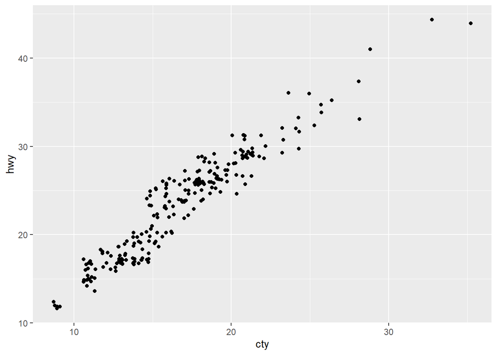

```r
ggplot(data = mpg, mapping = aes(x = cty, y = hwy)) +
  geom_jitter()
```

However, the reduction in overlapping comes at the cost of slightly changing the `x` and `y` values of the points.

The geom `geom_count()` sizes the points relative to the number of observations. Combinations of (`x`, `y`) values with more observations will be larger than those with fewer observations.

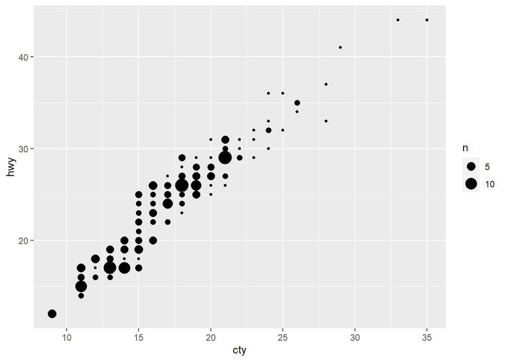

```r
ggplot(data = mpg, mapping = aes(x = cty, y = hwy)) +
  geom_count()
```

The `geom_count()` geom does not change `x` and `y` coordinates of the points. However, if the points are close together and counts are large, the size of some points can itself create overplotting. For example, in the following example, a third variable mapped to color is added to the plot. In this case, `geom_count()` is less readable than `geom_jitter()` when adding a third variable as a color aesthetic.

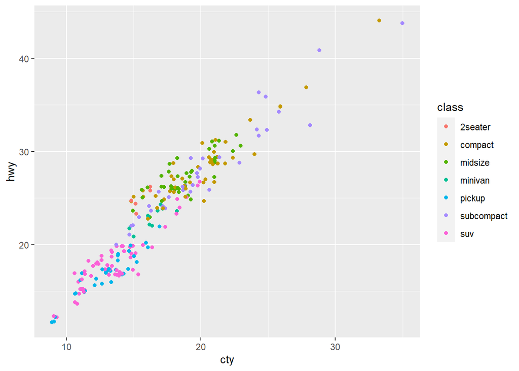

```r
ggplot(data = mpg, mapping = aes(x = cty, y = hwy, color = class)) +
  geom_jitter()
```

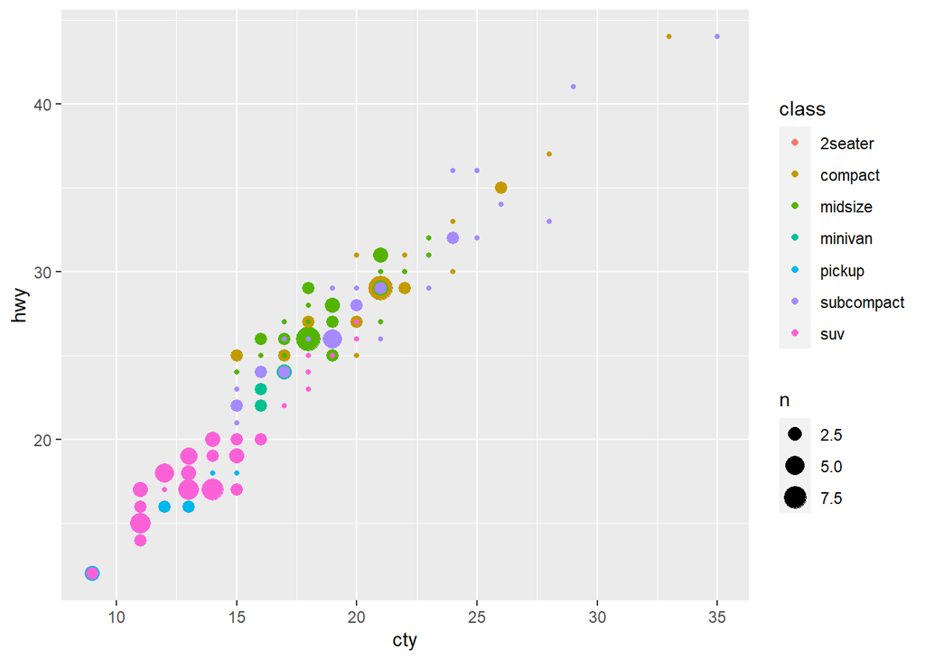

```r
ggplot(data = mpg, mapping = aes(x = cty, y = hwy, color = class)) +
  geom_count()
```

Combining `geom_count()` with jitter, which is specified with the `position` argument to `geom_count()` rather than its own geom, helps overplotting a little.

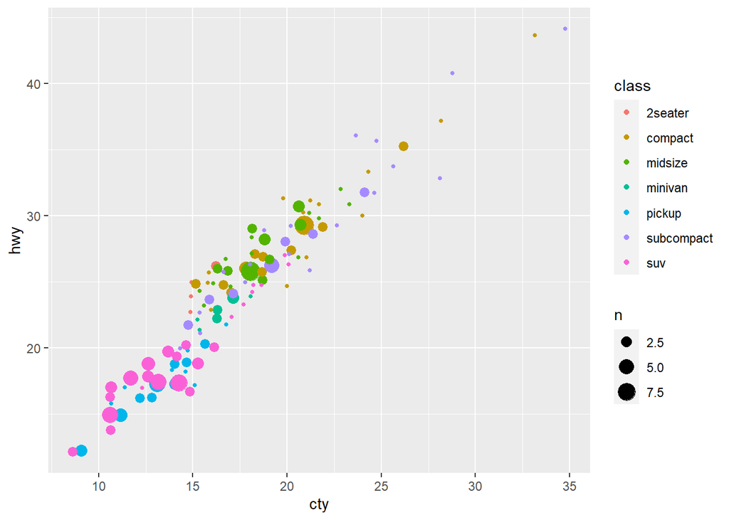

```r
ggplot(data = mpg, mapping = aes(x = cty, y = hwy, color = class)) +
  geom_count(position = "jitter")
```

But as this example shows, unfortunately, there is no universal solution to overplotting. The costs and benefits of different approaches will depend on the structure of the data and the goal of the data scientist.

### Exercise 3.8.4

What’s the default position adjustment for `geom_boxplot()`? Create a visualization of the `mpg` dataset that demonstrates it.

The default position for `geom_boxplot()` is `"dodge2"`, which is a shortcut for `position_dodge2`. This position adjustment does not change the vertical position of a geom but moves the geom horizontally to avoid overlapping other geoms. See the documentation for [`position_dodge2()`](https://ggplot2.tidyverse.org/reference/position_dodge.html) for additional discussion on how it works.

When we add `colour = class` to the box plot, the different levels of the `drv` variable are placed side by side, i.e., dodged.

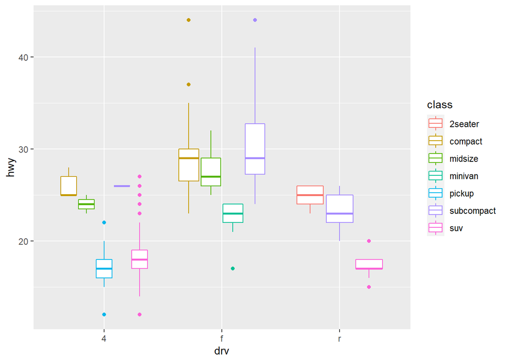

```r
ggplot(data = mpg, aes(x = drv, y = hwy, colour = class)) +
  geom_boxplot()
```

If `position_identity()` is used the boxplots overlap.

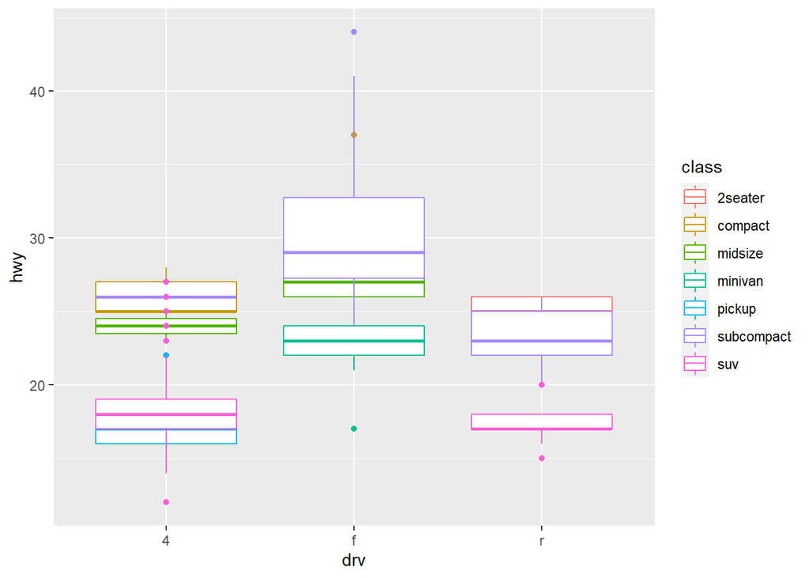

```r
ggplot(data = mpg, aes(x = drv, y = hwy, colour = class)) +
  geom_boxplot(position = "identity")
```

## Coordinate systems

### Exercise 3.9.1

Turn a stacked bar chart into a pie chart using `coord_polar()`.

A pie chart is a stacked bar chart with the addition of polar coordinates. Take this stacked bar chart with a single category.

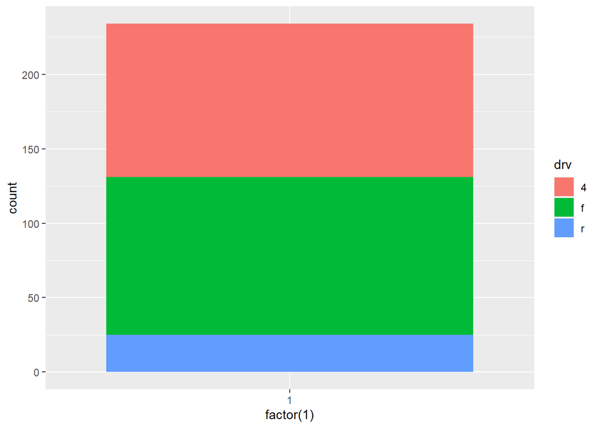

```r
ggplot(mpg, aes(x = factor(1), fill = drv)) +
  geom_bar()
```

Now add `coord_polar(theta="y")` to create pie chart.

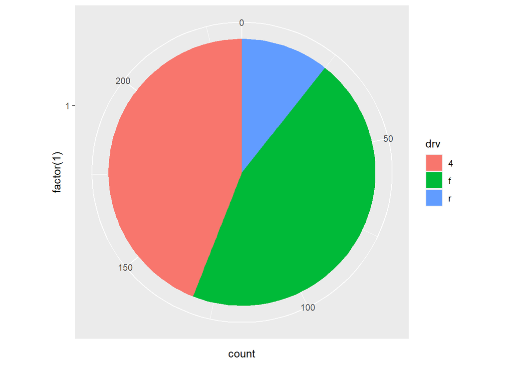

```r
ggplot(mpg, aes(x = factor(1), fill = drv)) +
  geom_bar(width = 1) +
  coord_polar(theta = "y")
```

The argument `theta = "y"` maps `y` to the angle of each section. If `coord_polar()` is specified without `theta = "y"`, then the resulting plot is called a bulls-eye chart.

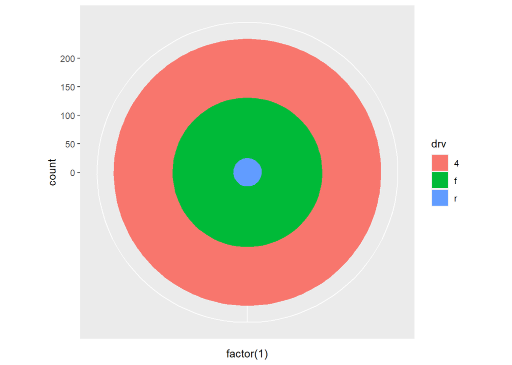

```r
ggplot(mpg, aes(x = factor(1), fill = drv)) +
  geom_bar(width = 1) +
  coord_polar()
```

### Exercise 3.9.2

What does `labs()` do? Read the documentation.

The `labs` function adds axis titles, plot titles, and a caption to the plot.

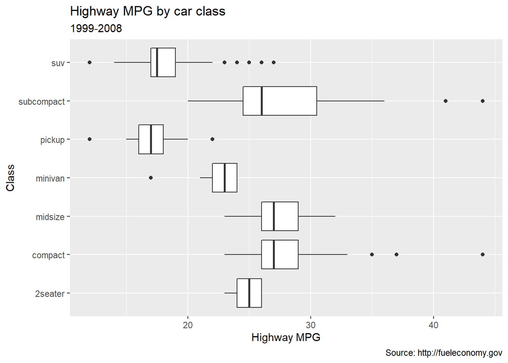

```r
ggplot(data = mpg, mapping = aes(x = class, y = hwy)) +
  geom_boxplot() +
  coord_flip() +
  labs(y = "Highway MPG",
       x = "Class",
       title = "Highway MPG by car class",
       subtitle = "1999-2008",
       caption = "Source: http://fueleconomy.gov")
```

The arguments to `labs()` are optional, so you can add as many or as few of these as are needed.

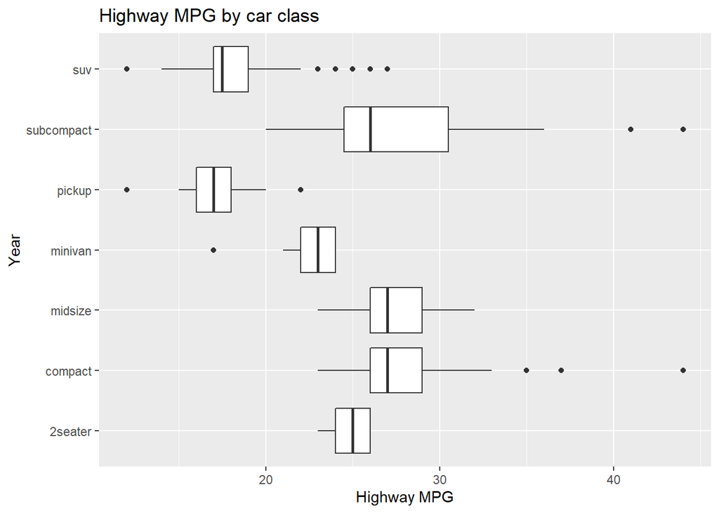

```r
ggplot(data = mpg, mapping = aes(x = class, y = hwy)) +
  geom_boxplot() +
  coord_flip() +
  labs(y = "Highway MPG",
       x = "Year",
       title = "Highway MPG by car class")
```

The `labs()` function is not the only function that adds titles to plots. The `xlab()`, `ylab()`, and x- and y-scale functions can add axis titles. The `ggtitle()` function adds plot titles.

### Exercise 3.9.3

What’s the difference between `coord_quickmap()` and `coord_map()`?

The `coord_map()` function uses map projections to project the three-dimensional Earth onto a two-dimensional plane. By default, `coord_map()` uses the [Mercator projection](https://en.wikipedia.org/wiki/Mercator_projection). This projection is applied to all the geoms in the plot. The `coord_quickmap()` function uses an approximate but faster map projection. This approximation ignores the curvature of Earth and adjusts the map for the latitude/longitude ratio. The `coord_quickmap()` project is faster than `coord_map()` both because the projection is computationally easier, and unlike `coord_map()`, the coordinates of the individual geoms do not need to be transformed.

See the [coord_map()](https://ggplot2.tidyverse.org/reference/coord_map.html) documentation for more information on these functions and some examples.

### Exercise 3.9.4

What does the plot below tell you about the relationship between city and highway mpg? Why is `coord_fixed()` important? What does `geom_abline()` do?

The function `coord_fixed()` ensures that the line produced by `geom_abline()` is at a 45-degree angle. A 45-degree line makes it easy to compare the highway and city mileage to the case in which city and highway MPG were equal.

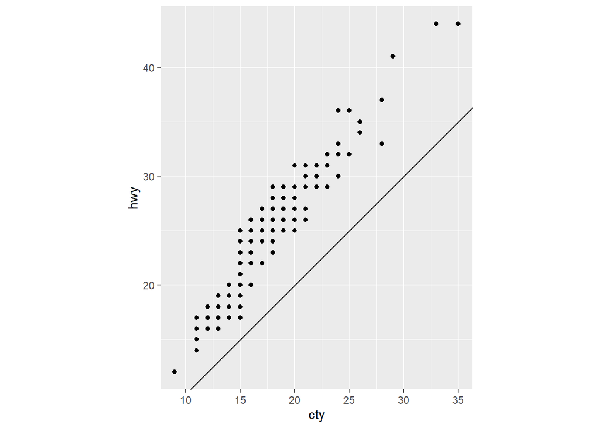

```r
p <- ggplot(data = mpg, mapping = aes(x = cty, y = hwy)) +
  geom_point() +
  geom_abline()
p + coord_fixed()
```

If we didn’t include `coord_fixed()`, then the line would no longer have an angle of 45 degrees.

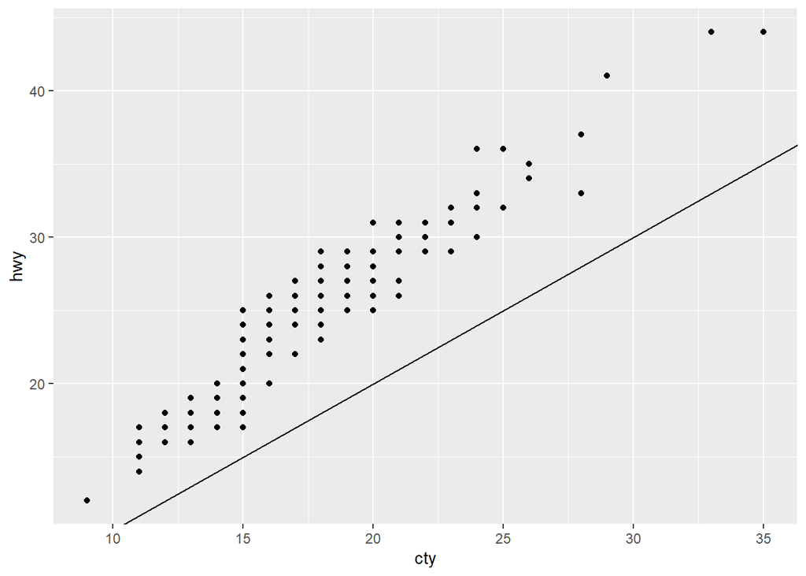

```r
p
```

On average, humans are best able to perceive differences in angles relative to 45 degrees. See @Cleveland1993, @Cleveland1994,@Cleveland1993a, @ClevelandMcGillMcGill1988, @HeerAgrawala2006 for discussion on how the aspect ratio of a plot affects perception of the values it encodes, evidence that 45-degrees is generally the optimal aspect ratio, and methods to calculate the optimal aspect ratio of a plot. The function `ggthemes::bank_slopes()` will calculate the optimal aspect ratio to bank slopes to 45-degrees.

## The layered grammar of graphics

[^1]: See the Wikipedia article on [Automobile layout](https://en.wikipedia.org/wiki/Automobile_layout).
[^2]: Internally, this is what the `factor` class, which is covered in [Chapter 15](https://r4ds.had.co.nz/factors.html), does.